# Reproducible Research: Peer Assessment 1

## Loading and preprocessing the data

### Unzip data file.

The original file is a csv file compressed into a zip.  
We uncompress the file **activity.zip** and store the uncompressed filename into *filename* variable.

Let’s load library dplyr to process and transform data in order to be able to work with it.

```r
library(dplyr)
```

```r
library(ggplot2)
library(xtable)
library(timeDate)
filename = unzip("activity.zip",overwrite = TRUE)
print (filename)
```

```
## [1] "./activity.csv"
```

After having the datafile uncompressed we can import that data, into a *data.frame* called **data**.

```r
data = read.table(filename,header = TRUE,sep = ",",stringsAsFactors=FALSE )
head (data)
```

```
##   steps       date interval
## 1    NA 2012-10-01        0
## 2    NA 2012-10-01        5
## 3    NA 2012-10-01       10
## 4    NA 2012-10-01       15
## 5    NA 2012-10-01       20
## 6    NA 2012-10-01       25
```

## What is mean total number of steps taken per day?

### Group data by date.

We group data by date in order to operate with those groups of information.

Then we will use group_by, from dplyr, to have a table grouped by date and to be able to find on mean steps in daily data.

In this step we ignore the NA values.

After this point we will have the folloing variables:  
- **data:** Full raw data from file  
- **table:** Full data without NA and grouped by data.  
- **step_mean:** Table with daily step means  
- **steps_interval:** Table grouped by intervals.  
- **steps_total:** Total sum of steps per day.

```r
table = na.omit (data)
table = group_by(table,date)
intervals = na.omit(data)
intervals = group_by(table,interval)

table$date = as.POSIXct(table$date)
step_mean = summarize(table,mean(steps))
colnames(step_mean) = c ( "date", "meanSteps")

steps_interval = summarize(intervals,mean(steps),median(steps))
colnames(steps_interval) = c("interval", "meanSteps","medianSteps")

steps_total = summarize(table,sum(steps))
colnames(steps_total) = c("date","steps")
steps_total
```

```
## Source: local data frame [53 x 2]
##
##          date steps
## 1  2012-10-02   126
## 2  2012-10-03 11352
## 3  2012-10-04 12116
## 4  2012-10-05 13294
## 5  2012-10-06 15420
## 6  2012-10-07 11015
## 7  2012-10-09 12811
## 8  2012-10-10  9900
## 9  2012-10-11 10304
## 10 2012-10-12 17382
## ..        ...   ...
```

Reporting the steps mean per day Print the mean values in a table:

```r
xt = xtable (step_mean)
print ( xt, type="html")
```

|  | date | meanSteps |
| --- | --- | --- |
| 1 | 2012-10-02 | 0.44 |
| 2 | 2012-10-03 | 39.42 |
| 3 | 2012-10-04 | 42.07 |
| 4 | 2012-10-05 | 46.16 |
| 5 | 2012-10-06 | 53.54 |
| 6 | 2012-10-07 | 38.25 |
| 7 | 2012-10-09 | 44.48 |
| 8 | 2012-10-10 | 34.38 |
| 9 | 2012-10-11 | 35.78 |
| 10 | 2012-10-12 | 60.35 |
| 11 | 2012-10-13 | 43.15 |
| 12 | 2012-10-14 | 52.42 |
| 13 | 2012-10-15 | 35.20 |
| 14 | 2012-10-16 | 52.38 |
| 15 | 2012-10-17 | 46.71 |
| 16 | 2012-10-18 | 34.92 |
| 17 | 2012-10-19 | 41.07 |
| 18 | 2012-10-20 | 36.09 |
| 19 | 2012-10-21 | 30.63 |
| 20 | 2012-10-22 | 46.74 |
| 21 | 2012-10-23 | 30.97 |
| 22 | 2012-10-24 | 29.01 |
| 23 | 2012-10-25 | 8.65 |
| 24 | 2012-10-26 | 23.53 |
| 25 | 2012-10-27 | 35.14 |
| 26 | 2012-10-28 | 39.78 |
| 27 | 2012-10-29 | 17.42 |
| 28 | 2012-10-30 | 34.09 |
| 29 | 2012-10-31 | 53.52 |
| 30 | 2012-11-02 | 36.81 |
| 31 | 2012-11-03 | 36.70 |
| 32 | 2012-11-05 | 36.25 |
| 33 | 2012-11-06 | 28.94 |
| 34 | 2012-11-07 | 44.73 |
| 35 | 2012-11-08 | 11.18 |
| 36 | 2012-11-11 | 43.78 |
| 37 | 2012-11-12 | 37.38 |
| 38 | 2012-11-13 | 25.47 |
| 39 | 2012-11-15 | 0.14 |
| 40 | 2012-11-16 | 18.89 |
| 41 | 2012-11-17 | 49.79 |
| 42 | 2012-11-18 | 52.47 |
| 43 | 2012-11-19 | 30.70 |
| 44 | 2012-11-20 | 15.53 |
| 45 | 2012-11-21 | 44.40 |
| 46 | 2012-11-22 | 70.93 |
| 47 | 2012-11-23 | 73.59 |
| 48 | 2012-11-24 | 50.27 |
| 49 | 2012-11-25 | 41.09 |
| 50 | 2012-11-26 | 38.76 |
| 51 | 2012-11-27 | 47.38 |
| 52 | 2012-11-28 | 35.36 |
| 53 | 2012-11-29 | 24.47 |

An histogram is an *one variable plot* where we count the frequency for the variable plotted.

Here we plot the frequency for all steps taken:

```
## stat_bin: binwidth defaulted to range/30. Use 'binwidth = x' to adjust this.
```

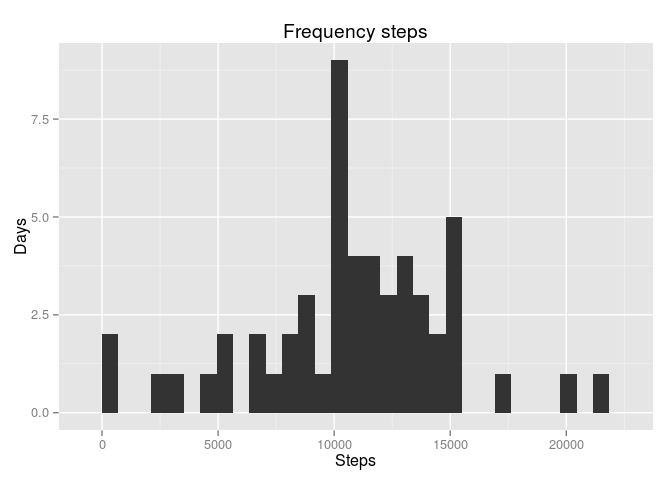

```r
qplot(x=steps,data=steps_total,geom="histogram", xlab="Steps", ylab="Days") + ggtitle("Frequency steps")
```

A barplot is a *two variables plot* where we can relate de values for the 2 variables.

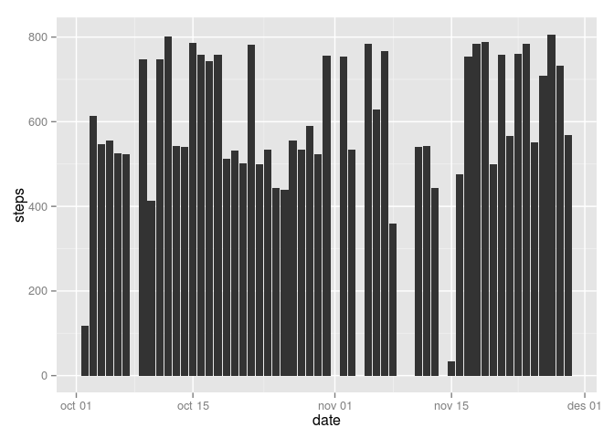

```r
qplot(x=date, y=steps,data=table, geom="bar", stat="identity",
position="dodge")
```

The median and mean for every interval is reported in the following table:

```r
xt = xtable (steps_interval)
print ( xt, type="html")
```

|  | interval | meanSteps | medianSteps |
| --- | --- | --- | --- |
| 1 | 0 | 1.72 | 0 |
| 2 | 5 | 0.34 | 0 |
| 3 | 10 | 0.13 | 0 |
| 4 | 15 | 0.15 | 0 |
| 5 | 20 | 0.08 | 0 |
| 6 | 25 | 2.09 | 0 |
| 7 | 30 | 0.53 | 0 |
| 8 | 35 | 0.87 | 0 |
| 9 | 40 | 0.00 | 0 |
| 10 | 45 | 1.47 | 0 |
| 11 | 50 | 0.30 | 0 |
| 12 | 55 | 0.13 | 0 |
| 13 | 100 | 0.32 | 0 |
| 14 | 105 | 0.68 | 0 |
| 15 | 110 | 0.15 | 0 |
| 16 | 115 | 0.34 | 0 |
| 17 | 120 | 0.00 | 0 |
| 18 | 125 | 1.11 | 0 |
| 19 | 130 | 1.83 | 0 |
| 20 | 135 | 0.17 | 0 |
| 21 | 140 | 0.17 | 0 |
| 22 | 145 | 0.38 | 0 |
| 23 | 150 | 0.26 | 0 |
| 24 | 155 | 0.00 | 0 |
| 25 | 200 | 0.00 | 0 |
| 26 | 205 | 0.00 | 0 |
| 27 | 210 | 1.13 | 0 |
| 28 | 215 | 0.00 | 0 |
| 29 | 220 | 0.00 | 0 |
| 30 | 225 | 0.13 | 0 |

[output cut: 258 more lines]

## What is the average daily activity pattern?

Let’s plot the linegraph gor the average steps per day interval taken.

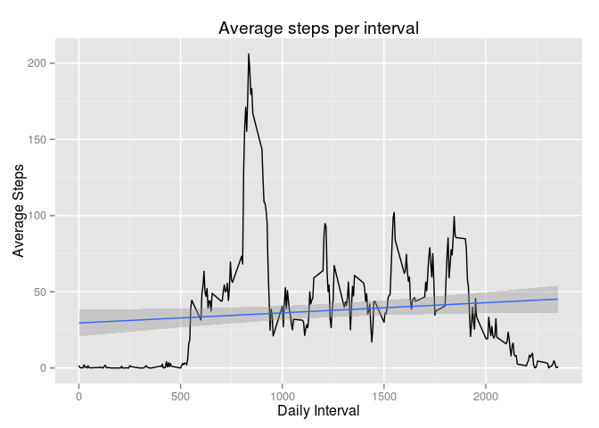

```r
qplot(steps_interval$interval, steps_interval$meanSteps, geom="line",xlab="Daily Interval",ylab="Average Steps")  + geom_smooth(method="lm") + ggtitle("Average steps per interval")
```

```r
steps_interval
```

```
## Source: local data frame [288 x 3]
##
##    interval meanSteps medianSteps
## 1         0 1.7169811           0
## 2         5 0.3396226           0
## 3        10 0.1320755           0
## 4        15 0.1509434           0
## 5        20 0.0754717           0
## 6        25 2.0943396           0
## 7        30 0.5283019           0
## 8        35 0.8679245           0
## 9        40 0.0000000           0
## 10       45 1.4716981           0
## ..      ...       ...         ...
```

```r
max(steps_interval$meanSteps)
```

```
## [1] 206.1698
```

## Imputing missing values

There are some NAs into original data. Actually there are:

```r
sum(is.na(data$steps))
```

```
## [1] 2304
```

Let’s fill the NA value with the mean value, into a new data.frame.

As there are only NA value into steps col, we can replace all NAs into data.frame.

```r
mean_value = mean(data$steps,na.rm=TRUE)

full_data = data
full_data[is.na(full_data)] = mean_value
sum(is.na(full_data))
```

```
## [1] 0
```

```r
full_table = group_by(full_data,date)
full_intervals = group_by(full_table,interval)

full_table$date = as.POSIXct(full_table$date)
full_step_mean = summarize(full_table,mean(steps),median(steps))
colnames(full_step_mean) = c ( "date", "meanSteps","medianSteps")

NA_table = group_by(data,date)
NA_step_mean = summarize(NA_table,mean(steps),median(steps))
colnames(NA_step_mean) = c ( "date", "meanSteps","medianSteps")


#full_steps_interval = summarize(full_intervals,mean(steps),median(steps))
#colnames(full_steps_interval) = c("interval", "meanSteps","medianSteps")

full_steps_total = summarize(full_table,sum(steps))
colnames(full_steps_total) = c("date","steps")
full_steps_total$date = as.POSIXct(full_steps_total$date)
```

Present all information calculed in last step.

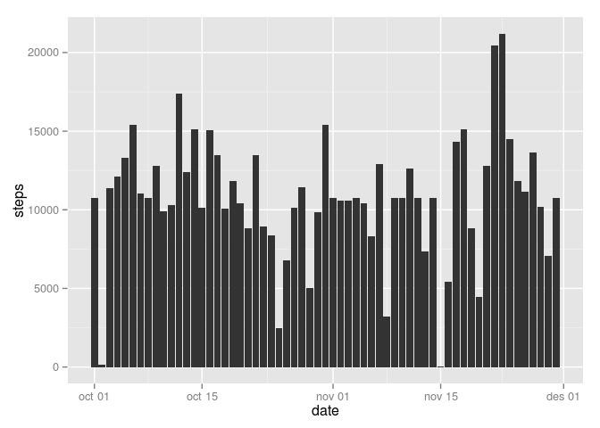

```r
qplot(x=date, y=steps,data=full_steps_total, geom="bar", stat="identity",
position="dodge")
```

Report about mean and median per day:

```r
xt = xtable (full_step_mean)
print ( xt, type="html")
```

|  | date | meanSteps | medianSteps |
| --- | --- | --- | --- |
| 1 | 2012-10-01 | 37.38 | 37.38 |
| 2 | 2012-10-02 | 0.44 | 0.00 |
| 3 | 2012-10-03 | 39.42 | 0.00 |
| 4 | 2012-10-04 | 42.07 | 0.00 |
| 5 | 2012-10-05 | 46.16 | 0.00 |
| 6 | 2012-10-06 | 53.54 | 0.00 |
| 7 | 2012-10-07 | 38.25 | 0.00 |
| 8 | 2012-10-08 | 37.38 | 37.38 |
| 9 | 2012-10-09 | 44.48 | 0.00 |
| 10 | 2012-10-10 | 34.38 | 0.00 |
| 11 | 2012-10-11 | 35.78 | 0.00 |
| 12 | 2012-10-12 | 60.35 | 0.00 |
| 13 | 2012-10-13 | 43.15 | 0.00 |
| 14 | 2012-10-14 | 52.42 | 0.00 |
| 15 | 2012-10-15 | 35.20 | 0.00 |
| 16 | 2012-10-16 | 52.38 | 0.00 |
| 17 | 2012-10-17 | 46.71 | 0.00 |
| 18 | 2012-10-18 | 34.92 | 0.00 |
| 19 | 2012-10-19 | 41.07 | 0.00 |
| 20 | 2012-10-20 | 36.09 | 0.00 |
| 21 | 2012-10-21 | 30.63 | 0.00 |
| 22 | 2012-10-22 | 46.74 | 0.00 |
| 23 | 2012-10-23 | 30.97 | 0.00 |
| 24 | 2012-10-24 | 29.01 | 0.00 |
| 25 | 2012-10-25 | 8.65 | 0.00 |
| 26 | 2012-10-26 | 23.53 | 0.00 |
| 27 | 2012-10-27 | 35.14 | 0.00 |
| 28 | 2012-10-28 | 39.78 | 0.00 |
| 29 | 2012-10-29 | 17.42 | 0.00 |
| 30 | 2012-10-30 | 34.09 | 0.00 |
| 31 | 2012-10-31 | 53.52 | 0.00 |
| 32 | 2012-11-01 | 37.38 | 37.38 |
| 33 | 2012-11-02 | 36.81 | 0.00 |
| 34 | 2012-11-03 | 36.70 | 0.00 |
| 35 | 2012-11-04 | 37.38 | 37.38 |
| 36 | 2012-11-05 | 36.25 | 0.00 |
| 37 | 2012-11-06 | 28.94 | 0.00 |
| 38 | 2012-11-07 | 44.73 | 0.00 |
| 39 | 2012-11-08 | 11.18 | 0.00 |
| 40 | 2012-11-09 | 37.38 | 37.38 |
| 41 | 2012-11-10 | 37.38 | 37.38 |
| 42 | 2012-11-11 | 43.78 | 0.00 |
| 43 | 2012-11-12 | 37.38 | 0.00 |
| 44 | 2012-11-13 | 25.47 | 0.00 |
| 45 | 2012-11-14 | 37.38 | 37.38 |
| 46 | 2012-11-15 | 0.14 | 0.00 |
| 47 | 2012-11-16 | 18.89 | 0.00 |
| 48 | 2012-11-17 | 49.79 | 0.00 |
| 49 | 2012-11-18 | 52.47 | 0.00 |
| 50 | 2012-11-19 | 30.70 | 0.00 |
| 51 | 2012-11-20 | 15.53 | 0.00 |
| 52 | 2012-11-21 | 44.40 | 0.00 |
| 53 | 2012-11-22 | 70.93 | 0.00 |
| 54 | 2012-11-23 | 73.59 | 0.00 |
| 55 | 2012-11-24 | 50.27 | 0.00 |
| 56 | 2012-11-25 | 41.09 | 0.00 |
| 57 | 2012-11-26 | 38.76 | 0.00 |
| 58 | 2012-11-27 | 47.38 | 0.00 |
| 59 | 2012-11-28 | 35.36 | 0.00 |
| 60 | 2012-11-29 | 24.47 | 0.00 |
| 61 | 2012-11-30 | 37.38 | 37.38 |

Mean diference between filled NA dataset and dataset without NAS: There is only a real diference in NA values.

```r
full_step_mean$meanSteps - NA_step_mean$meanSteps
```

```
##  [1] NA  0  0  0  0  0  0 NA  0  0  0  0  0  0  0  0  0  0  0  0  0  0  0
## [24]  0  0  0  0  0  0  0  0 NA  0  0 NA  0  0  0  0 NA NA  0  0  0 NA  0
## [47]  0  0  0  0  0  0  0  0  0  0  0  0  0  0 NA
```

Median diference between filled NA dataset and dataset without NAS:

```r
full_step_mean$medianSteps - NA_step_mean$medianSteps
```

```
##  [1] NA  0  0  0  0  0  0 NA  0  0  0  0  0  0  0  0  0  0  0  0  0  0  0
## [24]  0  0  0  0  0  0  0  0 NA  0  0 NA  0  0  0  0 NA NA  0  0  0 NA  0
## [47]  0  0  0  0  0  0  0  0  0  0  0  0  0  0 NA
```

## Are there differences in activity patterns between weekdays and weekends?

First we indentify weekdays and weekends.

```r
week_steps = table
week_steps = mutate(week_steps, weekday=isWeekday(date))
```

Process data to find mean:

```r
week_steps = group_by(week_steps,interval,weekday)
week_steps_interval = summarize(week_steps,mean(steps))
colnames(week_steps_interval) = c("interval","weekday","meanSteps")
```

Plot data.

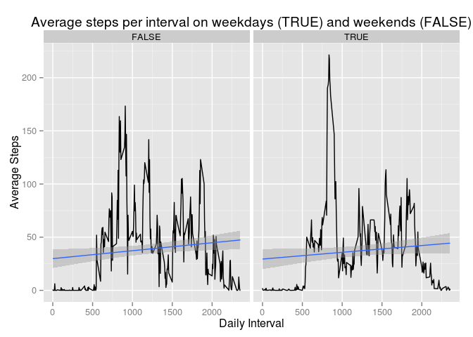

```r
qplot(interval, meanSteps,data=week_steps_interval, facets = . ~ weekday, geom="line",xlab="Daily Interval",ylab="Average Steps")  + geom_smooth(method="lm") + ggtitle("Average steps per interval on weekdays (TRUE) and weekends (FALSE)")
```

[output not shown]